# myMap

```r
library(myMap)
```

myMap is a package implementing an R6 class constructor to download a map from Stamen API:[http://maps.stamen.com].

A new object will be generated as the constructor ic called:

```r
myMap = MapStamen$new(left = 86.05, bottom = 27.21,
                      right = 87.81, top = 28.76,
                      mapType = "terrain-background", Zoom = 8)
```

This call generates a new object named “myMap” which is actually a map extracted from Stamen API.

## Arguments

A map which is going to be extracted from Stamen should be defined by a box. The lower-left and upper-rigt points coordinates of the box should therefor be passed as the arguments.

- left: Provides the lower-left longtitude of the box.
- bottom: Provides the lower-left latitude of the box.
- right: Provides the upper-right longitude.
- top: Provides the upper-right latitude.
- mapType: Provides the type of interest for map to be extracted out. It can be one of the following: “terrain”, “terrain-background”, “terrain-labels”, “terrain-lines”, “toner”, “toner-2010”, “toner-2011”, “toner-background”, “toner-hybrid”, “toner-labels”, “toner-lines”, “toner-lite”, “watercolor” .

  Each of these types will show a special characteristic of the area of interest. For the details see:[http://maps.stamen.com]
- Zoom: Provides the zoom level.

## Methods

### showMap

This method will show the myMap:

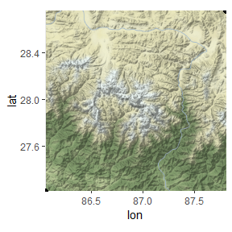

```r
myMap$showMap()
```

This is the map of the area of interest for the mapType = “terrain-background”.

If we set mapType = “terrain”:

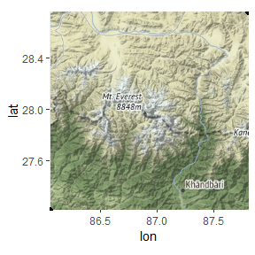

```r
myMap = MapStamen$new(left = 86.05, bottom = 27.21,
                      right = 87.81, top = 28.76,
                      mapType = "terrain", Zoom = 8)
myMap$showMap()
```

### saveMap

This method will save a png file of myMap in the working directory.

```r
myMap$saveMap()
```